# MC方法的改进——方差压缩技术(重要性抽样)

王宁宁

## MC 方法 回顾

$Z_N ^{MC}=E(f(X))=\frac{1}{N}\sum_{i=1}^N f(X_i)$

MC 的精度：

$MSE(Z_N ^{MC})=\frac{var(f(X))}{N}\equiv \mathcal{O}\left(\frac{1}{{N}}\right)$

而：

$RMSE(Z_N ^{MC})= \frac{stdev(f(X))}{\sqrt{N}}\equiv \mathcal{O}\left(\frac{1}{\sqrt{N}}\right)$ 这意味着精度如果想增加一位有效数字，样本量需要增加100倍。

下面考虑一种方差压缩技术：

设$X\sim \varphi(x)$，$Y\sim \psi(x)$，考虑$E(f(X))$的抽样估计

$\begin{align*}E(f(X))=&\int f(x) \varphi(x)\, dx\\ =&\int f(x)\frac{\varphi(x)}{\psi(x)}\psi(x)\,dx\\ =&E\left(f(Y)\frac{\varphi(Y)}{\psi(Y)}\right)\\ \equiv & Z_N^{IS}\end{align*}$

算法如下：

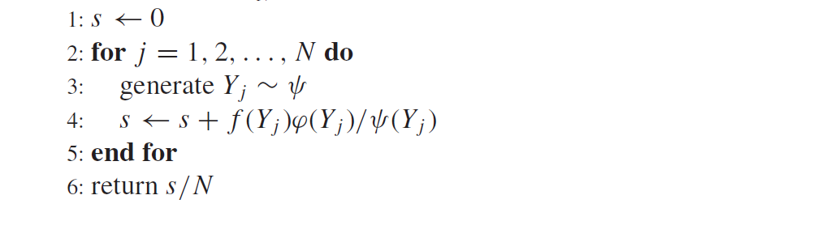

上述抽样方法称为**重要性抽样**。

## 重要性抽样的性质

- $bias(Z_N^{IS})=0$
- $\begin{align*}MSE(Z_N^{IS})=&\frac{1}{N}Var\left((f(X))\frac{\varphi(Y)}{\psi(Y)}\right)\\ =&\frac{1}{N}\left(Var(f(X))-E\left(f(X)^2\bigg(1-\frac{\varphi(X)}{\psi(X)}\bigg)\right)\right) \end{align*}$

$\psi$ 的选取：

$c_{\psi}=E\bigg(f(X)^2\big(1-\frac{\varphi(X)}{\psi(X)}\big)\bigg)>0$

- 上述 $c_\psi$ 尽可能得大。
- $Var\left((f(Y))\frac{\varphi(Y)}{\psi(Y)}\right)$ 尽可能的小。

### 重要性抽样的样本容量选择

$MSE(Z_N^{IS})=\frac{1}{N}Var\left((f(Y))\frac{\varphi(Y)}{\psi(Y)}\right)\approx\frac{\hat{\sigma}^2}{N}$

### 例子

设$X\sim N(0,1)$且$A=[3,4]$，现在要使用重要性抽样估计$P(X\in A)$，使用以下的辅助密度函数:

a、$Y\sim N(1,1)$

b、$Y\sim N(2,1)$

c、$Y\sim N(3.5,1)$

d、$Y\sim Exp(1)+3$

1、设计程序完成上述四种重要性抽样，各抽样10000次，比较四种方法的抽样误差。想一下哪一种抽样的精度最好？

2、假如想要$P(X\in A)$的精度达到0.01，每种方法各需要抽样多少次？